### What protein families do the interactors belong to?

To identify which protein families the interactors belong to, experimental pull down data represented on a volcano and scatter plots can be overlaid with information on protein families of enriched genes based on user-defined significance. This analysis can assist in functional annotation and exploration of the diversity of protein function in user’s proteomics experiment. Protein families can be visualized as avolcano plot using ‘ProteinFam: VP’ tab and as a scatter plot using ‘ProteinFam: SP’ tab. The protein family lists are taken from HGNC database curated by the HGNC appointed team.

### Protein families as volcano plot

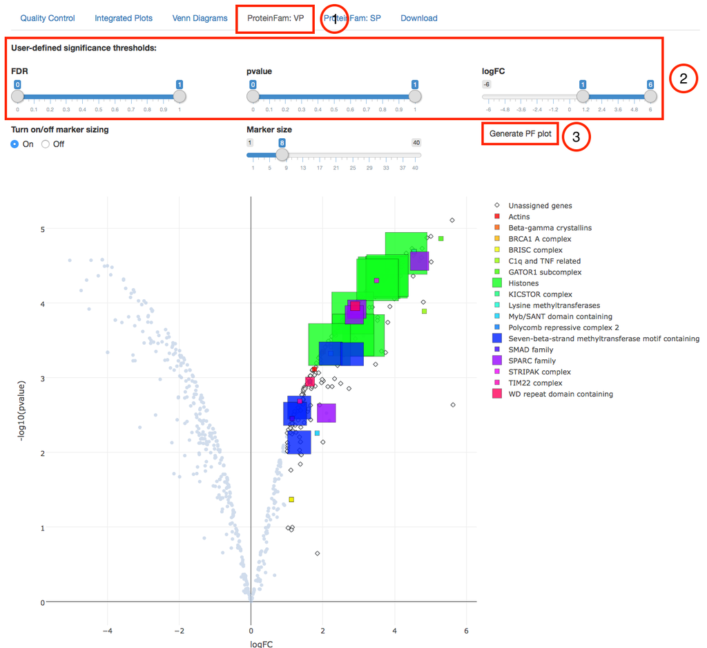

By default, the ‘Turn on/off marker sizing’ option is set as on and the user must select the variable to zoom/increase the markers by using the ‘Marker size’ slider as shown below.

**1. Marker sizing on**

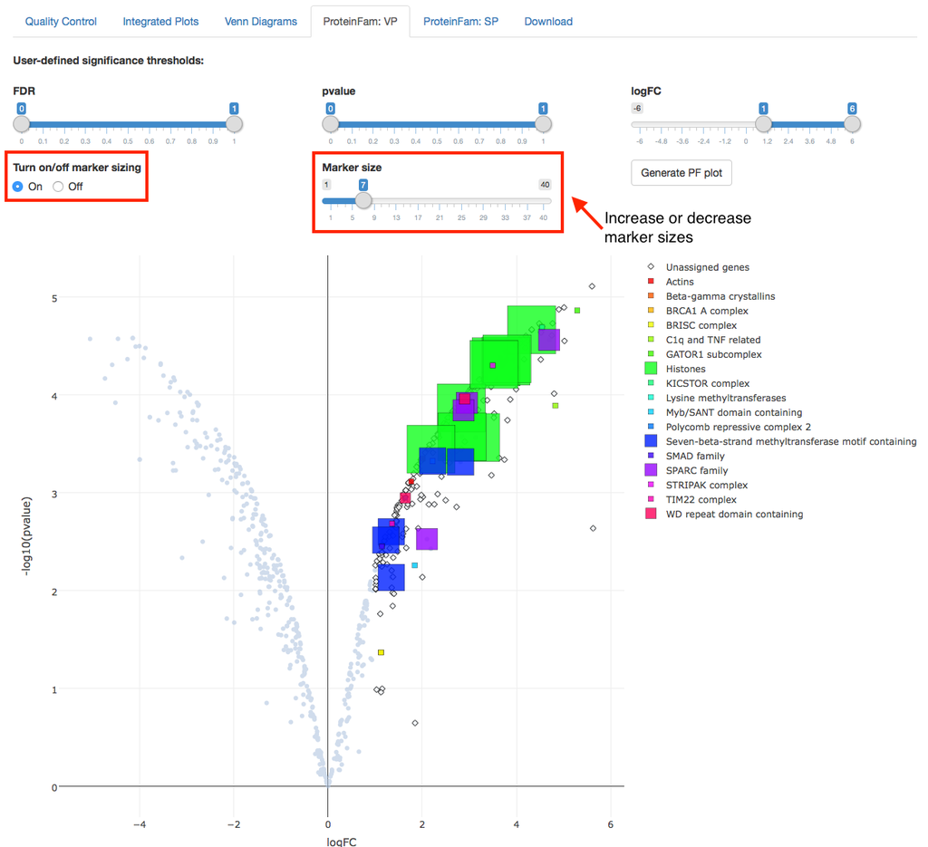

When marker sizing is turned on, the marker size is a direct representation of how many proteins belong to the same protein family, indicated by different colors. Hovering over the marker will display protein identifier using HGNC symbol, the protein family identified, and the number of other proteins belonging to the same protein family in user-defined region.

Turning off marking sizing will show uniform sized markers as shown in the figure below.

**2. Marker sizing off**

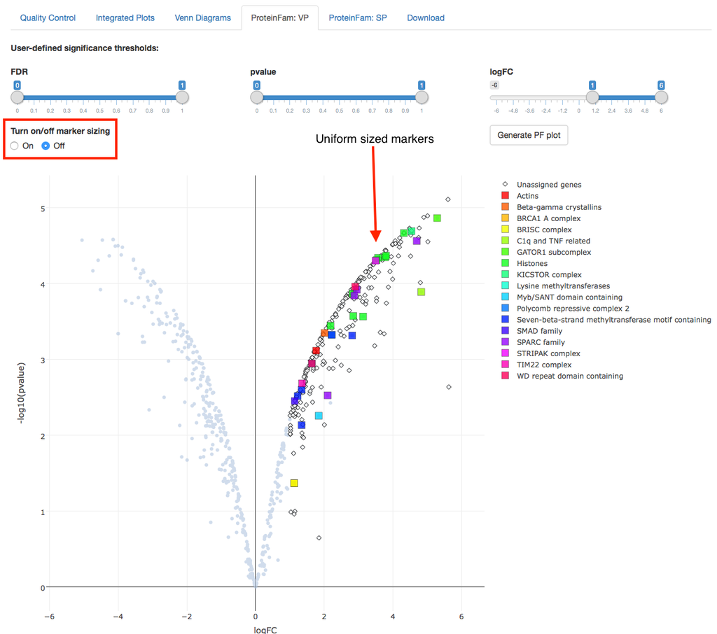

### Protein families as scatter plot

This scatter plot is applicable only if the uploaded proteomics data contains two replicates, rep1 and rep2. Visualizing protein families present as a scatter plot is especially useful when identifying general outliers and background contaminants, for example, proteins that interact with affinity reagent or epitope tag. These outliers and contaminants often have poor correlation between two replicates and are plotted outside of the diagonal as shown below.

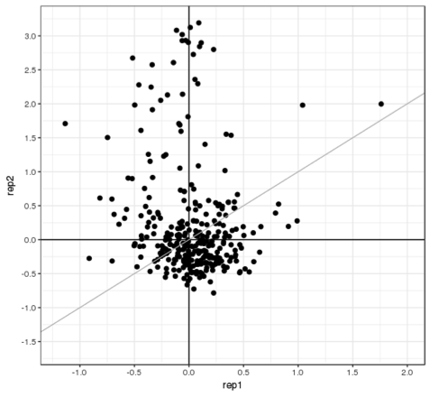

One method to troubleshoot and identify background contaminants from bona fide interactors is to identify which protein families the outliers belong to. User can define the limits of rep1 and rep2 values using the appropriate sliders and use the preview area on the right to select the region of interest as shown in the figure below.

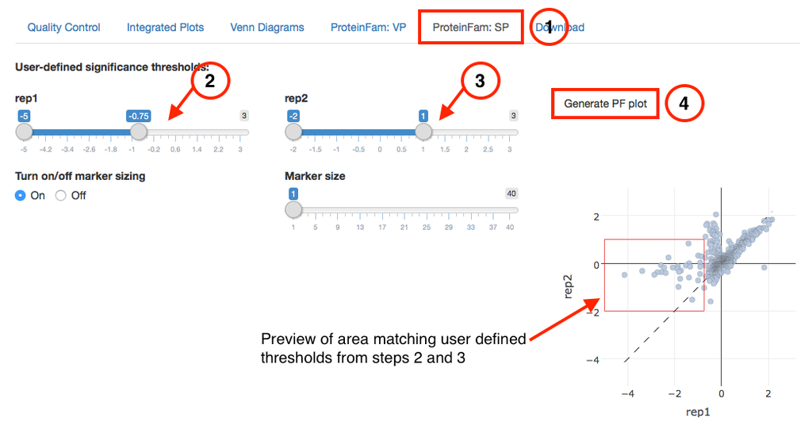